# WEEK 1A - Movie Ratings SQL & R Integration

Taha Malik

2025-09-08

## Introduction

This assignment shows how I took ratings for six recent movies from five friends, stored that info in a normalized SQL database, and then analyzed it in R. I made sure to handle missing data, since not everyone watched every movie. The process reflects real-world data work and demonstrates how SQL and R come together for data science projects.

## 1. Connect to MySQL and Load Data

First, I set up my R environment and connected to my MySQL database.  
This part makes sure I can pull the ratings data right from where it lives, instead of using static files.

```r
library(DBI)
library(RMySQL)
library(dplyr)
library(tidyr)
```

```r
# Set up your database connection parameters
db_host <- "localhost"
db_user <- "root"   #
db_password <- "--------" # <-- blank out before submitting!
db_name <- "movieratings"

# Connect to MySQL database
con <- dbConnect(RMySQL::MySQL(),
                 host = db_host,
                 user = db_user,
                 password = db_password,
                 dbname = db_name)

# Optional: Hide password in submission by using environment variables
# db_password <- Sys.getenv("DB_PASSWORD")
```

```r
# Pull the tables from SQL into R so I can work with them
friends <- dbReadTable(con, "friends")
movies <- dbReadTable(con, "movies")
ratings <- dbReadTable(con, "ratings")
```

## 2. Join Data and Create Ratings Matrix

Here, I join up the tables so I can see which friend rated which movie and what score they gave.  
I pivot the data so each friend is a row and each movie is a column, with NAs where ratings are missing.

```r
# Join all tables for a full ratings list
ratings_full <- ratings %>%
  left_join(friends, by = "friend_id") %>%
  left_join(movies, by = "movie_id") %>%
  select(name, title, year, rating)

# Pivot to wide format (friends x movies)
ratings_matrix <- ratings_full %>%
  pivot_wider(names_from = title, values_from = rating)

# Display the matrix
knitr::kable(ratings_matrix, caption = "Ratings Matrix (NA = Missing)")
```

Ratings Matrix (NA = Missing)

| name | year | Oppenheimer | Barbie | Spider-Man: Across the Spider-Verse | Guardians of the Galaxy Vol. 3 | Mission: Impossible – Dead Reckoning Part One | John Wick: Chapter 4 |
| --- | --- | --- | --- | --- | --- | --- | --- |
| Alice | 2023 | 5 | 4 | 5 | NA | NA | NA |
| Bob | 2023 | 4 | 5 | NA | 3 | NA | NA |
| Carol | 2023 | NA | NA | 3 | NA | 2 | NA |
| David | 2023 | NA | 2 | 4 | 5 | NA | 5 |
| Eve | 2023 | 3 | NA | NA | NA | NA | 4 |

## 3. Handling Missing Data

Not everyone saw every movie, so there are gaps in the data.  
This section counts how many ratings are missing for each friend and each movie, so I know where the holes are.  
Handling missing data is crucial for honest analysis.

```r
# How many ratings are missing per friend?
missing_per_friend <- ratings_matrix %>%
  mutate(missing = rowSums(is.na(select(., -name)))) %>%
  select(name, missing)

knitr::kable(missing_per_friend, caption = "Number of Missing Ratings per Friend")
```

Number of Missing Ratings per Friend

| name | missing |
| --- | --- |
| Alice | 3 |
| Bob | 3 |
| Carol | 4 |
| David | 2 |
| Eve | 4 |

```r
# How many ratings are missing per movie?
missing_per_movie <- colSums(is.na(ratings_matrix[,-1]))
missing_per_movie_df <- data.frame(movie = names(missing_per_movie), missing = missing_per_movie)
knitr::kable(missing_per_movie_df, caption = "Number of Missing Ratings per Movie")
```

Number of Missing Ratings per Movie

|  | movie | missing |
| --- | --- | --- |
| year | year | 0 |
| Oppenheimer | Oppenheimer | 2 |
| Barbie | Barbie | 2 |
| Spider-Man: Across the Spider-Verse | Spider-Man: Across the Spider-Verse | 2 |
| Guardians of the Galaxy Vol. 3 | Guardians of the Galaxy Vol. 3 | 3 |
| Mission: Impossible – Dead Reckoning Part One | Mission: Impossible – Dead Reckoning Part One | 4 |
| John Wick: Chapter 4 | John Wick: Chapter 4 | 3 |

## 4. Analysis: Average Ratings and Standardization

This part shows the average score for each movie, based only on friends who saw it.  
I also standardize ratings (z-score) so differences in scoring style between friends are factored out.  
This helps me compare movies fairly and spot any rating bias.

```r
# Average rating per movie (ignoring missing)
avg_ratings <- ratings_full %>%
  group_by(title) %>%
  summarize(mean_rating = round(mean(rating, na.rm = TRUE),2),
            num_ratings = n())

knitr::kable(avg_ratings, caption = "Average Ratings per Movie")
```

Average Ratings per Movie

| title | mean_rating | num_ratings |
| --- | --- | --- |
| Barbie | 3.67 | 3 |
| Guardians of the Galaxy Vol. 3 | 4.00 | 2 |
| John Wick: Chapter 4 | 4.50 | 2 |
| Mission: Impossible – Dead Reckoning Part One | 2.00 | 1 |
| Oppenheimer | 4.00 | 3 |
| Spider-Man: Across the Spider-Verse | 4.00 | 3 |

```r
# Standardize ratings per friend (z-score)
ratings_std <- ratings_full %>%
  group_by(name) %>%
  mutate(std_rating = scale(rating)) %>%
  ungroup()

knitr::kable(head(ratings_std), caption = "Standardized Ratings (first few rows)")
```

Standardized Ratings (first few rows)

| name | title | year | rating | std_rating |
| --- | --- | --- | --- | --- |
| Alice | Oppenheimer | 2023 | 5 | 0.5773503 |
| Alice | Barbie | 2023 | 4 | -1.1547005 |
| Alice | Spider-Man: Across the Spider-Verse | 2023 | 5 | 0.5773503 |
| Bob | Oppenheimer | 2023 | 4 | 0.0000000 |
| Bob | Barbie | 2023 | 5 | 1.0000000 |
| Bob | Guardians of the Galaxy Vol. 3 | 2023 | 3 | -1.0000000 |

## 5. Visualization (Optional)

Graphs make the results easier to understand.  
Here’s a bar chart showing the average ratings for each movie, so I can see which ones were most and least liked.

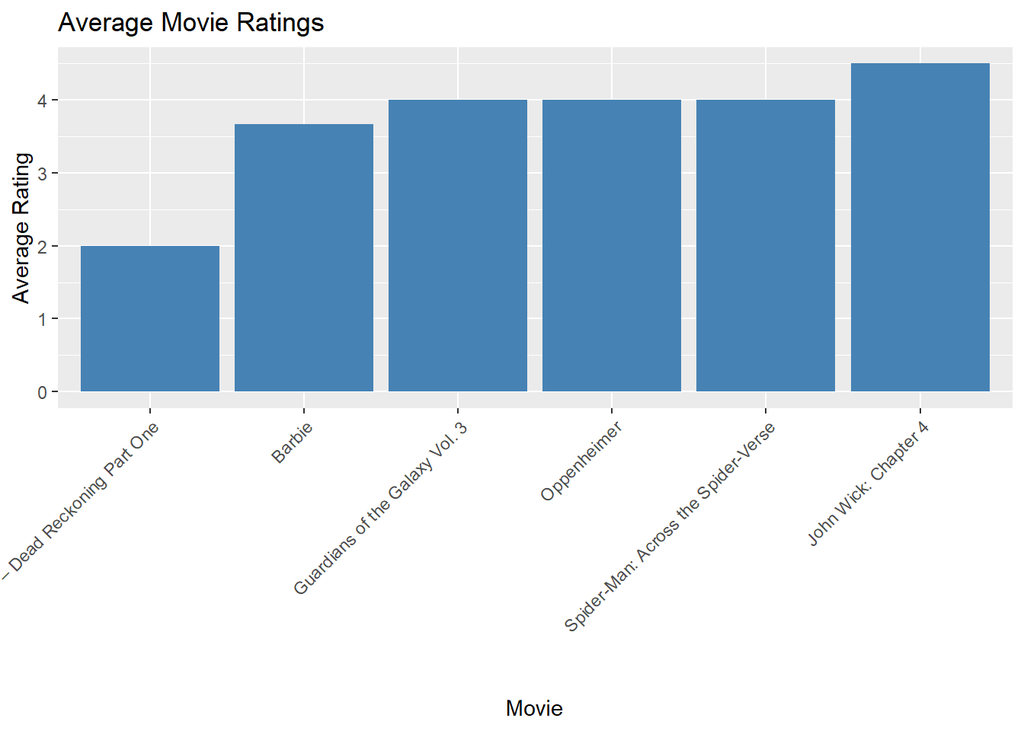

```r
library(ggplot2)
ggplot(avg_ratings, aes(x = reorder(title, mean_rating), y = mean_rating)) +
  geom_bar(stat = "identity", fill = "steelblue") +
  labs(title = "Average Movie Ratings", x = "Movie", y = "Average Rating") +
  theme(axis.text.x = element_text(angle = 45, hjust = 1))
```

## 6. Disconnect

Always clean up!  
Here I disconnect from the database so I don’t leave open connections.

```r
dbDisconnect(con)
```

```
## [1] TRUE
```

## 8. Members

Just Me! Taha Malik